# Final Project Discussion

CMSC471: Introduction to Information Visualization (Spring 2025)

The goal of this lab is to showcase your ideas, gather peer feedback, and refine your ideas. We’ve read all proposals and divided you into 7 groups. You work together to discuss these key topics, and TAs and I will circulate to provide guidance and ensure every team is supported.

See the group assignment below. You can find your group at the bottom of the Canvas page. The environment isn’t strictly “roundtable” style, so settle in where designated.

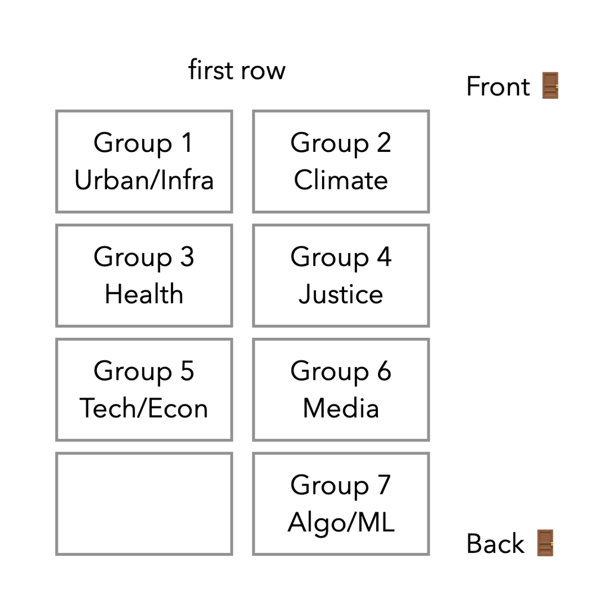

# Session Setup

Begin the session by moving to your assigned area. If you have more than 2 people in one team showing up, you can split up your team and choose to move to a different “table”. Course staff and TAs will circulate to check attendance, ensure every team is present, and join discussions as needed.

Open the [peer feedback spreadsheet](https://docs.google.com/spreadsheets/d/1MeofEvKzr20O-gtjUYWz2pAz3aRPJu_NLUnkfqHqBpQ/edit?usp=sharing) (UMD email) to record your peer feedback in the discussion. While this lab is mostly graded based on attendance, the course staff may check in if we feel the feedback quality needs improvement.

# Proposal Roundtable Discussion

Within each “roundtable”:

### Each team (or a representative) gives a brief summary (1–4 minutes) covering:

- An overview of the chosen dataset(s) and why they are complex enough
- The main visualization problem and the main visualization you plan to implement
- Key interactive or design ideas planned for the project
- One or two specific areas where targeted feedback is desired

### Then spends about 7–10 minutes per proposal, using these prompt questions to guide your discussion:

**Dataset selection & complexity**

- Is the dataset chosen **large**, **rich**, or **complex** enough to justify a dedicated visualization?
- Who is the **target audience**, and how is the project tailored for them?
- Is the visualization intended to be more **expressive** (insightful/story-driven) or **effective** (precise/data-driven)?

**Visual & narrative clarity**

- How clearly is the **visualization problem** defined?
- Does the current framing effectively **communicate a complex subject**?
- How could the visualization **design** be improved to better serve the story or user experience?

**Interactivity & technical feasibility**

- Are interactive features meaningfully defined? Do they **enhance the narrative** or exploration?
- What are the **main technical challenges** (e.g., data cleaning, D3 complexity)? How might they be addressed?

**Team collaboration & timeline**

- Are there plans to **integrate contributions** from all team members?
- Does the team demonstrate a **realistic timeline** and division of responsibilities?

# Shifts

If your table completes the discussion before the session ends, feel free to join other tables or seek out groups whose proposals interest you for further discussion.

Alternatively, approach course staff for additional feedback or to share insights on the discussions.